# Socioeconomic Status and Cancer

Jacob Park

Cancer is a disease that affects millions of people around the world. There are many different types of research that are done to show the correlation between certain types of foods or behaviors and cancer. With the increase in research of cancer around the world, there are new discoveries that are found everyday. There are socioeconomic factors that are correlated with the different types of cancer. Breast cancer and melanoma are positively correlated with income and race but lung cancer and colorectal cancer are negatively correlated with income.

```
##
## Call:
## lm_basic(formula = income ~ 1 + breast + colorectal + prostate +
##     lung + melanoma, data = cancer)
##
## Residuals:
##    Min     1Q Median     3Q    Max
## -26028  -6330  -1544   4879  61182
##
## Coefficients:
##              Estimate     2.5 %   97.5 %
## (Intercept) 43772.765 39848.456 47697.07
## breast        217.493   188.252   246.74
## colorectal   -217.786  -283.739  -151.83
## prostate       -0.294   -19.146    18.56
## lung         -243.309  -274.471  -212.15
## melanoma      205.480   140.866   270.09
##
## Residual standard error: 10170 on 1955 degrees of freedom
## Multiple R-squared:  0.3115, Adjusted R-squared:  0.3097
## F-statistic: 176.9 on 5 and 1955 DF,  p-value: < 2.2e-16
```

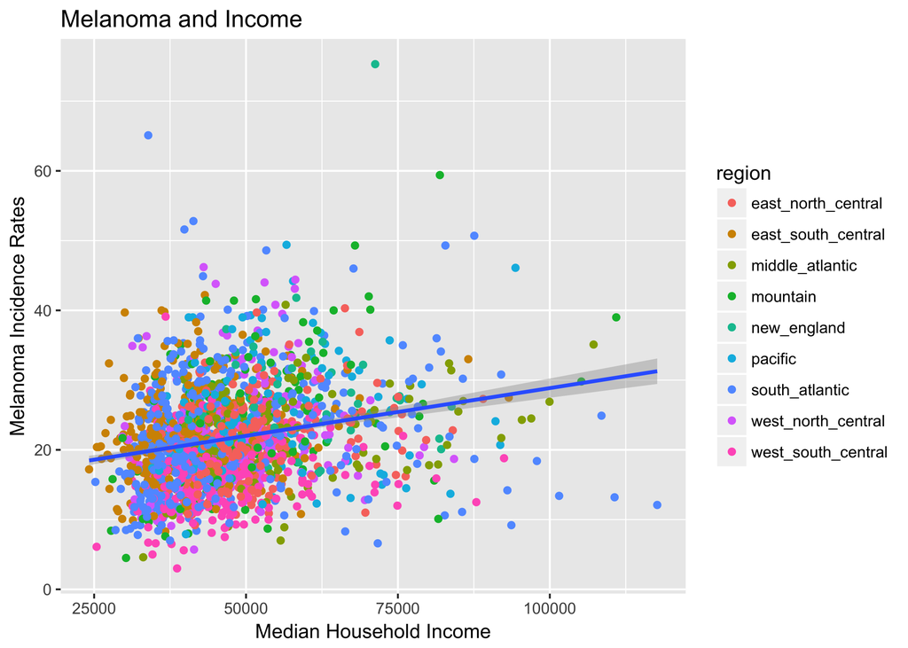

There is a correlation between income and the different cancer types. In the case of breast cancer and melanoma, there is a positive correlation between income. This is the case because women with higher income “tend to drink alcohol, have fewer children, use birth control, and use menopausal hormone therapy”(Socioeconomic). These are all factors that increases the risk of breast cancer. An analysis from Komen found that alocoholic consumption increased “the relative risk of breast cancer… by about 7%”(Socioeconomic). This is because alcohol can alter the estrogen level in women. For melanoma, the risk increases with exposure to UV. Affluent individuals are “more likely to take more tropical vacations or go to tanning salons more often” (Boyles). The relationship between breast cancer and melanoma rates and high income is very significant because the confidence levels do not contain zero. For around every $200 increase in income, the cancer incident rate for both breast cancer and melanoma increases by 1 for every 100,000 households.

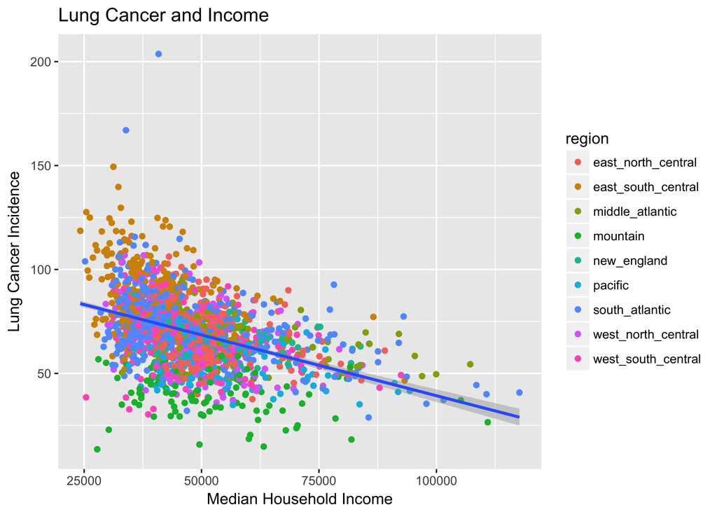

```
##
## Call:
## lm_basic(formula = poverty ~ 1 + region, data = cancer)
##
## Residuals:
##      Min       1Q   Median       3Q      Max
## -15.4135  -3.3615  -0.2615   3.0958  24.3709
##
## Coefficients:
##                          Estimate    2.5 % 97.5 %
## (Intercept)              14.20415 13.62522 14.783
## regioneast_south_central  6.70930  5.86276  7.556
## regionmiddle_atlantic    -0.40552 -1.43202  0.621
## regionmountain            1.72492  0.68609  2.764
## regionnew_england        -1.96569 -3.36179 -0.570
## regionpacific             2.42865  1.34495  3.512
## regionsouth_atlantic      4.15739  3.40524  4.910
## regionwest_north_central -0.07012 -1.01055  0.870
## regionwest_south_central  4.31185  3.44306  5.181
##
## Residual standard error: 5.223 on 1952 degrees of freedom
## Multiple R-squared:  0.1931, Adjusted R-squared:  0.1898
## F-statistic: 58.39 on 8 and 1952 DF,  p-value: < 2.2e-16
```

```
##
## Call:
## lm_basic(formula = breast ~ 1 + black_alone + white_alone + asian_alone,
##     data = cancer)
##
## Residuals:
##     Min      1Q  Median      3Q     Max
## -58.308  -9.779   0.198  10.189 138.647
##
## Coefficients:
##             Estimate   2.5 % 97.5 %
## (Intercept)  74.9392 62.7043 87.174
## black_alone   0.5563  0.4210  0.692
## white_alone   0.4161  0.2879  0.544
## asian_alone   1.8256  1.5046  2.147
##
## Residual standard error: 16.61 on 1957 degrees of freedom
## Multiple R-squared:  0.07521,    Adjusted R-squared:  0.0738
## F-statistic: 53.06 on 3 and 1957 DF,  p-value: < 2.2e-16
```

## References

Boyles, Salynn. “Melanoma Rates May Be Higher for the Rich.” WebMD, WebMD, 21 Mar. 2011, www.webmd.com/melanoma-skin-cancer/news/20110321/melanoma-rates-may-be-higher-for-the-rich#2.

“Breast Cancer in Asia | Gen Re.” Gen Re Perspective, www.genre.com/knowledge/publications/ri16-4-en.html.

Fincher, Leta Hong. “China Dropped Its One-Child Policy. So Why Aren’t Chinese Women Having More Babies?” The New York Times, The New York Times, 20 Feb. 2018, www.nytimes.com/2018/02/20/opinion/china-women-birthrate-rights.html.

“Socioeconomic Status.” Susan G. Komen®, ww5.komen.org/Breastcancer/Highsocioeconomicstatus.html.